# Herramientas para los TPs

- **Jupyter notebook o Jupyter lab**: herramienta para programar y ver datos a la vez
- **Pandas**: lib para trabajar con tablas de datos
- **Numpy**: lib para trabajar con arrays, y lo que usa pandas por dentro
- **Matplotlib o Plotly**: libs para graficar
- **Scikit learn**: lib para realizar machine learning
- **Keras**: lib específica para realizar machine learning con redes neuronales artificiales

# Instalación

Explicado en el [notebook de prueba de entorno](https://github.com/ucseml-team/machine-learning-course/blob/master/prueba_entorno.ipynb)!

# Jupyter

- Project Jupyter was born out of the IPython Project in 2014 as it evolved to support interactive data science and scientific computing across all programming languages.
- El notebook es un interprete interactivo en la web, pero que permite mezclar código, videos, imágenes, markdown, latex y gráficas...
- Un notebook es una sucesión de celdas, donde cada una puede ser código, texto, etc

### Labs vs Notebooks

- Un "notebook" es un documento en particular (similar a decir "un powerpoint", o "un word", etc).
- Se pueden abrir corriendo en la consola "jupyter notebook", y luego eligiendo en la web que se abre, el notebook correspondiente.
- O se pueden abrir corriendo en la consola "jupyter lab", y usando el IDE que se abre en la web para trabajar con muchos notebooks y más.
- Esto que estás viendo es un notebook!

### Uso

1. Abrir una consola
2. Moverse al directorio donde tienen los notebooks con los que van a trabajar
3. Correr `uv run jupyter notebook`, o `uv run jupyter lab`, dependiendo de lo que quieran usar.

# Pandas

- Permite trabajar con tablas de datos
- Muy rápido
- No tan intuitivo a veces, no tengan miedo de mirar la doc, tiene buenos ejemplos
- Se basa en dos estructuras de datos básicas: Series y DataFrames.

### Series vs DataFrames

- Una Serie es una secuencia de datos.
- Cada dato tiene un índice dentro de la serie.
- Un DataFrame es una tabla de datos (que también tiene un índice).
- Cada columna de un DataFrame es en realidad una Serie.

### Ejemplo: csv de pasadas de satélites

```python
from datetime import datetime, timedelta
import pytz
```

```python
import pandas as pd  # todo el mundo lo hace de esta forma
```

```python
passes = pd.read_csv('sate_passes.csv', parse_dates=[3, 4, 5])
```

```python
len(passes)
```

```
5354
```

```python
passes
```

|  | sate | nickname | norad_id | start | center | end | elevation |
| --- | --- | --- | --- | --- | --- | --- | --- |
| 0 | iss | zarya | 25544 | 2026-01-01 13:20:22.719820 | 2026-01-01 13:25:38.468354 | 2026-01-01 13:30:59.772581 | 29.367578 |
| 1 | iss | zarya | 25544 | 2026-01-01 14:57:31.424407 | 2026-01-01 15:02:40.691299 | 2026-01-01 15:07:53.661987 | 21.158438 |
| 2 | iss | zarya | 25544 | 2026-01-01 21:31:07.155678 | 2026-01-01 21:36:34.015597 | 2026-01-01 21:41:58.097671 | 38.055570 |
| 3 | iss | zarya | 25544 | 2026-01-01 23:08:33.773288 | 2026-01-01 23:13:18.039563 | 2026-01-01 23:18:01.379890 | 14.229771 |
| 4 | iss | zarya | 25544 | 2026-01-02 12:36:34.286268 | 2026-01-02 12:41:28.737979 | 2026-01-02 12:46:26.893487 | 17.120171 |
| ... | ... | ... | ... | ... | ... | ... | ... |
| 5349 | newsat-50 | nancy | 60493 | 2026-12-30 03:51:33.769963 | 2026-12-30 03:56:54.063770 | 2026-12-30 04:02:11.547983 | 30.671785 |
| 5350 | newsat-50 | nancy | 60493 | 2026-12-30 14:19:31.104203 | 2026-12-30 14:24:47.651883 | 2026-12-30 14:30:10.755285 | 33.130246 |
| 5351 | newsat-50 | nancy | 60493 | 2026-12-31 03:21:13.660330 | 2026-12-31 03:26:48.938643 | 2026-12-31 03:32:20.470829 | 87.579599 |
| 5352 | newsat-50 | nancy | 60493 | 2026-12-31 13:50:14.258657 | 2026-12-31 13:54:48.662415 | 2026-12-31 13:59:27.748832 | 13.077914 |
| 5353 | newsat-50 | nancy | 60493 | 2026-12-31 15:22:25.910097 | 2026-12-31 15:27:34.965525 | 2026-12-31 15:32:50.576675 | 24.429499 |

5354 rows × 7 columns

```python
passes.sample(10)
```

|  | sate | nickname | norad_id | start | center | end | elevation |
| --- | --- | --- | --- | --- | --- | --- | --- |
| 4676 | newsat-50 | nancy | 60493 | 2026-05-05 14:37:35.910035 | 2026-05-05 14:43:12.124879 | 2026-05-05 14:48:55.831977 | 88.839068 |
| 481 | iss | zarya | 25544 | 2026-05-08 20:37:45.234745 | 2026-05-08 20:43:01.909227 | 2026-05-08 20:48:14.879915 | 28.089691 |
| 3746 | newsat-48 | henrietta | 60498 | 2026-06-10 13:38:10.398963 | 2026-06-10 13:42:41.172192 | 2026-06-10 13:47:14.756217 | 11.549282 |
| 65 | iss | zarya | 25544 | 2026-01-18 15:23:54.283062 | 2026-01-18 15:29:28.550572 | 2026-01-18 15:34:59.114287 | 83.674759 |
| 3716 | newsat-48 | henrietta | 60498 | 2026-05-31 02:48:08.109488 | 2026-05-31 02:53:36.972476 | 2026-05-31 02:59:02.087739 | 33.530004 |
| 5055 | newsat-50 | nancy | 60493 | 2026-09-16 03:51:33.296113 | 2026-09-16 03:56:50.780325 | 2026-09-16 04:02:05.454943 | 26.777186 |
| 908 | iss | zarya | 25544 | 2026-08-31 23:14:58.678149 | 2026-08-31 23:20:05.167195 | 2026-08-31 23:25:08.878395 | 22.004767 |
| 2127 | newsat-34 | amelia | 55045 | 2026-10-04 01:17:43.974616 | 2026-10-04 01:22:45.263157 | 2026-10-04 01:27:42.808983 | 17.747277 |
| 4995 | newsat-50 | nancy | 60493 | 2026-08-26 02:51:09.293696 | 2026-08-26 02:56:37.079756 | 2026-08-26 03:02:00.183158 | 34.766600 |
| 2381 | newsat-37 | joan | 56203 | 2026-01-01 15:21:23.523750 | 2026-01-01 15:26:44.909124 | 2026-01-01 15:32:01.703279 | 76.781112 |

### Filtrado de datos

```python
passes[["nickname", "center", "elevation"]]
```

|  | nickname | center | elevation |
| --- | --- | --- | --- |
| 0 | zarya | 2026-01-01 13:25:38.468354 | 29.367578 |
| 1 | zarya | 2026-01-01 15:02:40.691299 | 21.158438 |
| 2 | zarya | 2026-01-01 21:36:34.015597 | 38.055570 |
| 3 | zarya | 2026-01-01 23:13:18.039563 | 14.229771 |
| 4 | zarya | 2026-01-02 12:41:28.737979 | 17.120171 |
| ... | ... | ... | ... |
| 5349 | nancy | 2026-12-30 03:56:54.063770 | 30.671785 |
| 5350 | nancy | 2026-12-30 14:24:47.651883 | 33.130246 |
| 5351 | nancy | 2026-12-31 03:26:48.938643 | 87.579599 |
| 5352 | nancy | 2026-12-31 13:54:48.662415 | 13.077914 |
| 5353 | nancy | 2026-12-31 15:27:34.965525 | 24.429499 |

5354 rows × 3 columns

```python
amelia_passes = passes[passes.nickname == "amelia"]

amelia_passes
```

|  | sate | nickname | norad_id | start | center | end | elevation |
| --- | --- | --- | --- | --- | --- | --- | --- |
| 1359 | newsat-34 | amelia | 55045 | 2026-01-01 01:19:07.516746 | 2026-01-01 01:24:20.033431 | 2026-01-01 01:29:28.807401 | 20.430510 |
| 1360 | newsat-34 | amelia | 55045 | 2026-01-01 02:52:35.734054 | 2026-01-01 02:57:33.279880 | 2026-01-01 03:02:28.954348 | 16.578526 |
| 1361 | newsat-34 | amelia | 55045 | 2026-01-01 13:22:21.405098 | 2026-01-01 13:27:59.185108 | 2026-01-01 13:33:43.514869 | 80.127140 |
| 1362 | newsat-34 | amelia | 55045 | 2026-01-02 02:27:35.875308 | 2026-01-02 02:33:05.234210 | 2026-01-02 02:38:30.850396 | 34.994205 |
| 1363 | newsat-34 | amelia | 55045 | 2026-01-02 12:58:00.074302 | 2026-01-02 13:03:25.690489 | 2026-01-02 13:08:56.920748 | 33.184494 |
| ... | ... | ... | ... | ... | ... | ... | ... |
| 2375 | newsat-34 | amelia | 55045 | 2026-12-30 02:24:26.715517 | 2026-12-30 02:29:55.138740 | 2026-12-30 02:35:19.819247 | 45.248779 |
| 2376 | newsat-34 | amelia | 55045 | 2026-12-30 12:51:48.353961 | 2026-12-30 12:56:50.578181 | 2026-12-30 13:01:59.352151 | 22.130877 |
| 2377 | newsat-34 | amelia | 55045 | 2026-12-30 14:25:01.579769 | 2026-12-30 14:29:41.347700 | 2026-12-30 14:34:28.601060 | 13.951652 |
| 2378 | newsat-34 | amelia | 55045 | 2026-12-31 01:52:06.998343 | 2026-12-31 01:57:39.164281 | 2026-12-31 02:03:05.716146 | 52.031575 |
| 2379 | newsat-34 | amelia | 55045 | 2026-12-31 13:51:53.537544 | 2026-12-31 13:57:14.475338 | 2026-12-31 14:02:43.834239 | 40.295589 |

1021 rows × 7 columns

```python
first_half_passes = passes[passes.start.dt.month < 7]

first_half_passes
```

|  | sate | nickname | norad_id | start | center | end | elevation |
| --- | --- | --- | --- | --- | --- | --- | --- |
| 0 | iss | zarya | 25544 | 2026-01-01 13:20:22.719820 | 2026-01-01 13:25:38.468354 | 2026-01-01 13:30:59.772581 | 29.367578 |
| 1 | iss | zarya | 25544 | 2026-01-01 14:57:31.424407 | 2026-01-01 15:02:40.691299 | 2026-01-01 15:07:53.661987 | 21.158438 |
| 2 | iss | zarya | 25544 | 2026-01-01 21:31:07.155678 | 2026-01-01 21:36:34.015597 | 2026-01-01 21:41:58.097671 | 38.055570 |
| 3 | iss | zarya | 25544 | 2026-01-01 23:08:33.773288 | 2026-01-01 23:13:18.039563 | 2026-01-01 23:18:01.379890 | 14.229771 |
| 4 | iss | zarya | 25544 | 2026-01-02 12:36:34.286268 | 2026-01-02 12:41:28.737979 | 2026-01-02 12:46:26.893487 | 17.120171 |
| ... | ... | ... | ... | ... | ... | ... | ... |
| 4832 | newsat-50 | nancy | 60493 | 2026-06-29 13:33:54.487562 | 2026-06-29 13:38:12.970283 | 2026-06-29 13:42:36.135663 | 10.006803 |
| 4833 | newsat-50 | nancy | 60493 | 2026-06-29 15:05:42.560442 | 2026-06-29 15:11:04.727312 | 2026-06-29 15:16:35.322967 | 33.626249 |
| 4834 | newsat-50 | nancy | 60493 | 2026-06-30 02:36:20.626842 | 2026-06-30 02:41:38.111054 | 2026-06-30 02:46:51.849141 | 23.099105 |
| 4835 | newsat-50 | nancy | 60493 | 2026-06-30 04:09:49.342438 | 2026-06-30 04:14:38.730702 | 2026-06-30 04:19:27.182435 | 14.743892 |
| 4836 | newsat-50 | nancy | 60493 | 2026-06-30 14:38:27.112806 | 2026-06-30 14:43:59.581524 | 2026-06-30 14:49:40.479026 | 88.545150 |

2687 rows × 7 columns

```python
first_half_passes.sample(10)
```

|  | sate | nickname | norad_id | start | center | end | elevation |
| --- | --- | --- | --- | --- | --- | --- | --- |
| 3745 | newsat-48 | henrietta | 60498 | 2026-06-10 03:07:10.701811 | 2026-06-10 03:12:49.871047 | 2026-06-10 03:18:24.355626 | 67.281061 |
| 2749 | newsat-37 | joan | 56203 | 2026-05-22 03:37:21.053584 | 2026-05-22 03:42:04.790956 | 2026-05-22 03:46:54.037793 | 20.584004 |
| 4422 | newsat-50 | nancy | 60493 | 2026-02-05 15:07:31.131228 | 2026-02-05 15:12:53.298098 | 2026-02-05 15:18:22.957221 | 29.103927 |
| 3600 | newsat-48 | henrietta | 60498 | 2026-04-20 13:44:36.096191 | 2026-04-20 13:49:24.671121 | 2026-04-20 13:54:18.867641 | 15.028115 |
| 2440 | newsat-37 | joan | 56203 | 2026-01-23 03:45:17.417624 | 2026-01-23 03:49:41.871874 | 2026-01-23 03:54:13.672076 | 12.675668 |
| 1732 | newsat-34 | amelia | 55045 | 2026-05-15 01:00:27.951257 | 2026-05-15 01:05:03.040795 | 2026-05-15 01:09:35.323295 | 11.200642 |
| 4594 | newsat-50 | nancy | 60493 | 2026-04-06 14:44:05.703494 | 2026-04-06 14:49:40.045275 | 2026-04-06 14:55:22.815841 | 69.033623 |
| 2411 | newsat-37 | joan | 56203 | 2026-01-12 15:15:51.698129 | 2026-01-12 15:21:11.247015 | 2026-01-12 15:26:26.204682 | 60.123002 |
| 1688 | newsat-34 | amelia | 55045 | 2026-04-29 14:02:41.783537 | 2026-04-29 14:07:54.300222 | 2026-04-29 14:13:13.366658 | 24.073733 |
| 52 | iss | zarya | 25544 | 2026-01-15 09:26:55.027403 | 2026-01-15 09:32:08.924039 | 2026-01-15 09:37:27.450419 | 23.466563 |

```python
today = datetime.utcnow()

when_to_see_amelia = passes[
    (passes.nickname == "amelia")
    & (passes.elevation > 25)
    & passes.start.between(today,
                           today + timedelta(days=2))
    & (
        (passes.start.dt.hour >= 9)
        | (passes.start.dt.hour < 2)
    )
]

when_to_see_amelia
```

|  | sate | nickname | norad_id | start | center | end | elevation |
| --- | --- | --- | --- | --- | --- | --- | --- |
| 1949 | newsat-34 | amelia | 55045 | 2026-08-01 01:48:15.041435 | 2026-08-01 01:53:48.143052 | 2026-08-01 01:59:17.501953 | 53.264312 |
| 1950 | newsat-34 | amelia | 55045 | 2026-08-01 13:49:50.050566 | 2026-08-01 13:55:13.795395 | 2026-08-01 14:00:44.089975 | 37.544088 |

```python
when_to_see_amelia.iloc[0]
```

```
sate                          newsat-34
nickname                         amelia
norad_id                          55045
start        2026-08-01 01:48:15.041435
center       2026-08-01 01:53:48.143052
end          2026-08-01 01:59:17.501953
elevation                     53.264312
Name: 1949, dtype: object
```

```python
when_to_see_amelia.iloc[0].elevation
```

```
53.264311726717054
```

### Describir datos

```python
passes.elevation.describe()
```

```
count    5354.000000
mean       34.491324
std        21.798521
min        10.003049
25%        16.526733
50%        27.232597
75%        47.887458
max        89.337540
Name: elevation, dtype: float64
```

```python
passes.nickname.unique()
```

```
array(['zarya', 'amelia', 'joan', 'henrietta', 'nancy'], dtype=object)
```

```python
passes.nickname.value_counts()
```

```
nickname
zarya        1359
henrietta    1033
nancy        1032
amelia       1021
joan          909
Name: count, dtype: int64
```

```python
passes.nickname.value_counts()['nancy']
```

```
1032
```

### Operar columnas

```python
durations = passes.end - passes.start

durations
```

```
0      0 days 00:10:37.052761
1      0 days 00:10:22.237580
2      0 days 00:10:50.941993
3      0 days 00:09:27.606602
4      0 days 00:09:52.607219
                ...
5349   0 days 00:10:37.778020
5350   0 days 00:10:39.651082
5351   0 days 00:11:06.810499
5352   0 days 00:09:13.490175
5353   0 days 00:10:24.666578
Length: 5354, dtype: timedelta64[ns]
```

```python
durations.describe()
```

```
count                         5354
mean     0 days 00:10:13.543356705
std      0 days 00:00:48.670373768
min         0 days 00:07:31.776011
25%      0 days 00:09:36.028433250
50%         0 days 00:10:23.059509
75%         0 days 00:10:55.910766
max         0 days 00:11:24.896994
dtype: object
```

```python
passes['duration'] = durations
```

```python
passes.sample(5)
```

|  | sate | nickname | norad_id | start | center | end | elevation | duration |
| --- | --- | --- | --- | --- | --- | --- | --- | --- |
| 1757 | newsat-34 | amelia | 55045 | 2026-05-24 03:07:20.163549 | 2026-05-24 03:11:45.896300 | 2026-05-24 03:16:11.629049 | 10.540257 | 0 days 00:08:51.465500 |
| 453 | iss | zarya | 25544 | 2026-05-01 14:37:10.309044 | 2026-05-01 14:42:40.872758 | 2026-05-01 14:48:17.918114 | 88.433018 | 0 days 00:11:07.609070 |
| 4691 | newsat-50 | nancy | 60493 | 2026-05-11 03:04:00.367081 | 2026-05-11 03:09:39.391520 | 2026-05-11 03:15:12.796769 | 63.979659 | 0 days 00:11:12.429688 |
| 4185 | newsat-48 | henrietta | 60498 | 2026-11-12 15:45:56.580311 | 2026-11-12 15:50:29.227404 | 2026-11-12 15:55:08.433019 | 11.821000 | 0 days 00:09:11.852708 |
| 3960 | newsat-48 | henrietta | 60498 | 2026-08-24 03:51:57.801804 | 2026-08-24 03:57:17.295476 | 2026-08-24 04:02:33.041424 | 26.946135 | 0 days 00:10:35.239620 |

```python
del passes['center']
del passes['end']
```

```python
passes.sample(5)
```

|  | sate | nickname | norad_id | start | elevation | duration |
| --- | --- | --- | --- | --- | --- | --- |
| 2507 | newsat-37 | joan | 56203 | 2026-02-18 03:24:40.052889 | 25.318191 | 0 days 00:10:00.531527 |
| 2939 | newsat-37 | joan | 56203 | 2026-08-05 15:17:41.485450 | 27.682723 | 0 days 00:09:35.738941 |
| 1304 | iss | zarya | 25544 | 2026-12-17 04:33:07.951762 | 28.326926 | 0 days 00:10:24.089477 |
| 3696 | newsat-48 | henrietta | 60498 | 2026-05-24 02:43:06.519950 | 28.577664 | 0 days 00:10:46.482799 |
| 1763 | newsat-34 | amelia | 55045 | 2026-05-26 12:41:21.491509 | 19.324516 | 0 days 00:10:05.384118 |

```python
passes[passes.duration > timedelta(minutes=11)]
```

|  | sate | nickname | norad_id | start | elevation | duration |
| --- | --- | --- | --- | --- | --- | --- |
| 8 | iss | zarya | 25544 | 2026-01-03 13:28:25.727496 | 56.405536 | 0 days 00:11:04.831224 |
| 11 | iss | zarya | 25544 | 2026-01-04 12:44:05.634668 | 79.394683 | 0 days 00:11:07.609070 |
| 14 | iss | zarya | 25544 | 2026-01-04 20:55:06.070376 | 83.234757 | 0 days 00:11:02.979327 |
| 17 | iss | zarya | 25544 | 2026-01-05 20:10:47.407320 | 53.407065 | 0 days 00:11:00.201480 |
| 26 | iss | zarya | 25544 | 2026-01-08 11:23:37.457450 | 72.177552 | 0 days 00:11:09.460968 |
| ... | ... | ... | ... | ... | ... | ... |
| 5334 | newsat-50 | nancy | 60493 | 2026-12-25 03:16:00.215281 | 73.071806 | 0 days 00:11:05.873968 |
| 5339 | newsat-50 | nancy | 60493 | 2026-12-26 14:46:47.672761 | 87.547019 | 0 days 00:11:04.937436 |
| 5342 | newsat-50 | nancy | 60493 | 2026-12-28 03:18:42.305645 | 80.426279 | 0 days 00:11:05.873967 |
| 5347 | newsat-50 | nancy | 60493 | 2026-12-29 14:49:24.054418 | 80.114701 | 0 days 00:11:04.937436 |
| 5351 | newsat-50 | nancy | 60493 | 2026-12-31 03:21:13.660330 | 87.579599 | 0 days 00:11:06.810499 |

1126 rows × 6 columns

```python
passes['duration_seconds'] = passes.duration.dt.total_seconds()

passes.sample(5)
```

|  | sate | nickname | norad_id | start | elevation | duration | duration_seconds |
| --- | --- | --- | --- | --- | --- | --- | --- |
| 845 | iss | zarya | 25544 | 2026-08-16 04:01:00.319462 | 31.074503 | 0 days 00:10:38.904657 | 638.904657 |
| 3995 | newsat-48 | henrietta | 60498 | 2026-09-06 02:34:30.766477 | 19.064246 | 0 days 00:10:09.005535 | 609.005535 |
| 5342 | newsat-50 | nancy | 60493 | 2026-12-28 03:18:42.305645 | 80.426279 | 0 days 00:11:05.873967 | 665.873967 |
| 4931 | newsat-50 | nancy | 60493 | 2026-08-03 04:12:13.493912 | 14.024259 | 0 days 00:09:28.474682 | 568.474682 |
| 5090 | newsat-50 | nancy | 60493 | 2026-09-29 02:21:29.623312 | 12.775351 | 0 days 00:09:23.792023 | 563.792023 |

```python
passes['is_good'] = (passes.duration_seconds > 600) & (passes.elevation > 30)

passes.sample(10)
```

|  | sate | nickname | norad_id | start | elevation | duration | duration_seconds | is_good |
| --- | --- | --- | --- | --- | --- | --- | --- | --- |
| 4161 | newsat-48 | henrietta | 60498 | 2026-11-04 02:53:25.979912 | 32.607301 | 0 days 00:10:51.167457 | 651.167457 | True |
| 4234 | newsat-48 | henrietta | 60498 | 2026-11-30 02:48:51.239890 | 26.527671 | 0 days 00:10:35.239620 | 635.239620 | False |
| 3257 | newsat-37 | joan | 56203 | 2026-12-18 04:13:57.112935 | 16.830830 | 0 days 00:08:18.606452 | 498.606452 | False |
| 4878 | newsat-50 | nancy | 60493 | 2026-07-15 15:37:35.728251 | 12.805813 | 0 days 00:09:24.728555 | 564.728555 | False |
| 3901 | newsat-48 | henrietta | 60498 | 2026-08-03 14:32:53.198724 | 66.621702 | 0 days 00:11:13.653815 | 673.653815 | True |
| 3220 | newsat-37 | joan | 56203 | 2026-12-01 16:04:57.333622 | 76.477212 | 0 days 00:09:10.946355 | 550.946355 | False |
| 2235 | newsat-34 | amelia | 55045 | 2026-11-10 02:30:24.814961 | 34.311812 | 0 days 00:10:40.004230 | 640.004230 | True |
| 3126 | newsat-37 | joan | 56203 | 2026-10-21 03:46:26.000446 | 31.175845 | 0 days 00:09:13.701086 | 553.701086 | False |
| 2776 | newsat-37 | joan | 56203 | 2026-06-02 02:10:16.817566 | 13.130987 | 0 days 00:08:39.726062 | 519.726062 | False |
| 2356 | newsat-34 | amelia | 55045 | 2026-12-23 03:04:50.571896 | 12.750619 | 0 days 00:09:11.114754 | 551.114754 | False |

```python
passes.is_good.value_counts()
```

```
is_good
False    3130
True     2224
Name: count, dtype: int64
```

```python
passes[passes.nickname == "amelia"].is_good.value_counts()
```

```
is_good
False    553
True     468
Name: count, dtype: int64
```

```python
full_names = passes.sate + " (" + passes.nickname + ")"

full_names
```

```
0             iss (zarya)
1             iss (zarya)
2             iss (zarya)
3             iss (zarya)
4             iss (zarya)
              ...
5349    newsat-50 (nancy)
5350    newsat-50 (nancy)
5351    newsat-50 (nancy)
5352    newsat-50 (nancy)
5353    newsat-50 (nancy)
Length: 5354, dtype: object
```

```python
full_names.unique()
```

```
array(['iss (zarya)', 'newsat-34 (amelia)', 'newsat-37 (joan)',
       'newsat-48 (henrietta)', 'newsat-50 (nancy)'], dtype=object)
```

### Ordenamiento

```python
sorted_passes = passes.sort_values("start")

sorted_passes
```

|  | sate | nickname | norad_id | start | elevation | duration | duration_seconds | is_good |
| --- | --- | --- | --- | --- | --- | --- | --- | --- |
| 1359 | newsat-34 | amelia | 55045 | 2026-01-01 01:19:07.516746 | 20.430510 | 0 days 00:10:21.290655 | 621.290655 | False |
| 2380 | newsat-37 | joan | 56203 | 2026-01-01 02:26:22.395494 | 34.027698 | 0 days 00:10:11.550454 | 611.550454 | True |
| 3289 | newsat-48 | henrietta | 60498 | 2026-01-01 02:36:10.962450 | 25.877514 | 0 days 00:10:48.356662 | 648.356662 | False |
| 1360 | newsat-34 | amelia | 55045 | 2026-01-01 02:52:35.734054 | 16.578526 | 0 days 00:09:53.220294 | 593.220294 | False |
| 4322 | newsat-50 | nancy | 60493 | 2026-01-01 03:22:37.233767 | 59.120700 | 0 days 00:11:18.048878 | 678.048878 | True |
| ... | ... | ... | ... | ... | ... | ... | ... | ... |
| 4321 | newsat-48 | henrietta | 60498 | 2026-12-31 15:11:16.970532 | 37.544896 | 0 days 00:10:52.104388 | 652.104388 | True |
| 5353 | newsat-50 | nancy | 60493 | 2026-12-31 15:22:25.910097 | 24.429499 | 0 days 00:10:24.666578 | 624.666578 | False |
| 3288 | newsat-37 | joan | 56203 | 2026-12-31 15:45:42.806536 | 20.723926 | 0 days 00:08:25.034159 | 505.034159 | False |
| 1357 | iss | zarya | 25544 | 2026-12-31 20:47:55.805404 | 14.917574 | 0 days 00:09:35.014192 | 575.014192 | False |
| 1358 | iss | zarya | 25544 | 2026-12-31 22:24:08.265410 | 46.429915 | 0 days 00:10:42.608453 | 642.608453 | True |

5354 rows × 8 columns

```python
passes
```

|  | sate | nickname | norad_id | start | elevation | duration | duration_seconds | is_good |
| --- | --- | --- | --- | --- | --- | --- | --- | --- |
| 0 | iss | zarya | 25544 | 2026-01-01 13:20:22.719820 | 29.367578 | 0 days 00:10:37.052761 | 637.052761 | False |
| 1 | iss | zarya | 25544 | 2026-01-01 14:57:31.424407 | 21.158438 | 0 days 00:10:22.237580 | 622.237580 | False |
| 2 | iss | zarya | 25544 | 2026-01-01 21:31:07.155678 | 38.055570 | 0 days 00:10:50.941993 | 650.941993 | True |
| 3 | iss | zarya | 25544 | 2026-01-01 23:08:33.773288 | 14.229771 | 0 days 00:09:27.606602 | 567.606602 | False |
| 4 | iss | zarya | 25544 | 2026-01-02 12:36:34.286268 | 17.120171 | 0 days 00:09:52.607219 | 592.607219 | False |
| ... | ... | ... | ... | ... | ... | ... | ... | ... |
| 5349 | newsat-50 | nancy | 60493 | 2026-12-30 03:51:33.769963 | 30.671785 | 0 days 00:10:37.778020 | 637.778020 | True |
| 5350 | newsat-50 | nancy | 60493 | 2026-12-30 14:19:31.104203 | 33.130246 | 0 days 00:10:39.651082 | 639.651082 | True |
| 5351 | newsat-50 | nancy | 60493 | 2026-12-31 03:21:13.660330 | 87.579599 | 0 days 00:11:06.810499 | 666.810499 | True |
| 5352 | newsat-50 | nancy | 60493 | 2026-12-31 13:50:14.258657 | 13.077914 | 0 days 00:09:13.490175 | 553.490175 | False |
| 5353 | newsat-50 | nancy | 60493 | 2026-12-31 15:22:25.910097 | 24.429499 | 0 days 00:10:24.666578 | 624.666578 | False |

5354 rows × 8 columns

```python
passes = passes.sort_values("start")

passes
```

|  | sate | nickname | norad_id | start | elevation | duration | duration_seconds | is_good |
| --- | --- | --- | --- | --- | --- | --- | --- | --- |
| 1359 | newsat-34 | amelia | 55045 | 2026-01-01 01:19:07.516746 | 20.430510 | 0 days 00:10:21.290655 | 621.290655 | False |
| 2380 | newsat-37 | joan | 56203 | 2026-01-01 02:26:22.395494 | 34.027698 | 0 days 00:10:11.550454 | 611.550454 | True |
| 3289 | newsat-48 | henrietta | 60498 | 2026-01-01 02:36:10.962450 | 25.877514 | 0 days 00:10:48.356662 | 648.356662 | False |
| 1360 | newsat-34 | amelia | 55045 | 2026-01-01 02:52:35.734054 | 16.578526 | 0 days 00:09:53.220294 | 593.220294 | False |
| 4322 | newsat-50 | nancy | 60493 | 2026-01-01 03:22:37.233767 | 59.120700 | 0 days 00:11:18.048878 | 678.048878 | True |
| ... | ... | ... | ... | ... | ... | ... | ... | ... |
| 4321 | newsat-48 | henrietta | 60498 | 2026-12-31 15:11:16.970532 | 37.544896 | 0 days 00:10:52.104388 | 652.104388 | True |
| 5353 | newsat-50 | nancy | 60493 | 2026-12-31 15:22:25.910097 | 24.429499 | 0 days 00:10:24.666578 | 624.666578 | False |
| 3288 | newsat-37 | joan | 56203 | 2026-12-31 15:45:42.806536 | 20.723926 | 0 days 00:08:25.034159 | 505.034159 | False |
| 1357 | iss | zarya | 25544 | 2026-12-31 20:47:55.805404 | 14.917574 | 0 days 00:09:35.014192 | 575.014192 | False |
| 1358 | iss | zarya | 25544 | 2026-12-31 22:24:08.265410 | 46.429915 | 0 days 00:10:42.608453 | 642.608453 | True |

5354 rows × 8 columns

### Agrupamiento

```python
passes.groupby("nickname").aggregate({"elevation": "mean", "duration": "max", "start": "count"})
```

| nickname | elevation | duration | start |
| --- | --- | --- | --- |
| amelia | 35.053819 | 0 days 00:11:22.109771 | 1021 |
| henrietta | 34.880094 | 0 days 00:11:24.896994 | 1033 |
| joan | 34.147532 | 0 days 00:10:38.179529 | 909 |
| nancy | 34.847212 | 0 days 00:11:22.731537 | 1032 |
| zarya | 33.732917 | 0 days 00:11:12.238815 | 1359 |

### Joins

```python
from_satellogic = pd.DataFrame(
    [
        ("zarya", False),
        ("amelia", True),
        ("joan", True),
        ("henrietta", True),
        ("nancy", True),
    ],
    columns=["nickname", "is_satellogic"],
)

from_satellogic
```

|  | nickname | is_satellogic |
| --- | --- | --- |
| 0 | zarya | False |
| 1 | amelia | True |
| 2 | joan | True |
| 3 | henrietta | True |
| 4 | nancy | True |

```python
from_satellogic = from_satellogic.set_index("nickname")

from_satellogic
```

| nickname | is_satellogic |
| --- | --- |
| zarya | False |
| amelia | True |
| joan | True |
| henrietta | True |
| nancy | True |

```python
passes = passes.join(from_satellogic, on="nickname")
```

```python
passes.sample(5)
```

|  | sate | nickname | norad_id | start | elevation | duration | duration_seconds | is_good | is_satellogic |
| --- | --- | --- | --- | --- | --- | --- | --- | --- | --- |
| 737 | iss | zarya | 25544 | 2026-07-16 15:46:08.148348 | 20.554820 | 0 days 00:10:09.274297 | 609.274297 | False | False |
| 3718 | newsat-48 | henrietta | 60498 | 2026-05-31 14:50:56.365046 | 58.011771 | 0 days 00:11:14.590747 | 674.590747 | True | True |
| 4755 | newsat-50 | nancy | 60493 | 2026-06-02 04:15:45.329478 | 11.985673 | 0 days 00:09:07.870985 | 547.870985 | False | True |
| 2143 | newsat-34 | amelia | 55045 | 2026-10-10 01:21:38.120162 | 19.885027 | 0 days 00:10:08.191154 | 608.191154 | False | True |
| 1982 | newsat-34 | amelia | 55045 | 2026-08-13 02:12:38.695149 | 61.025493 | 0 days 00:11:05.267555 | 665.267555 | True | True |

```python
(passes.is_good & passes.is_satellogic).value_counts()
```

```
False    3724
True     1630
Name: count, dtype: int64
```

```python
passes.dtypes
```

```
sate                         object
nickname                     object
norad_id                      int64
start                datetime64[ns]
elevation                   float64
duration            timedelta64[ns]
duration_seconds            float64
is_good                        bool
is_satellogic                  bool
dtype: object
```

### Y si los datos no entran en ram??

- Dask. Pero no lo vamos a ver.

# Numpy

- Lib para manejar arrays de cualquier cantidad de dimensiones (NxMxOx...)
- Bastante más bajo nivel que pandas
- Pandas usa numpy por dentro

```python
import numpy as np  # todo el mundo lo hace de esta forma
```

```python
arr = np.array([10, 20, 25, 4, 6])

arr  # de 5
```

```
array([10, 20, 25,  4,  6])
```

```python
arr[3]
```

```
4
```

```python
arr2 = np.random.random(100)

arr2  # de 100
```

```
array([5.50431711e-01, 3.26474694e-01, 4.11325150e-02, 3.77713827e-01,
       6.63588753e-01, 6.89335323e-02, 7.07450615e-01, 3.47396473e-01,
       3.10719046e-01, 1.18948009e-01, 8.84017641e-01, 8.17029524e-01,
       6.82623923e-01, 9.27093742e-01, 9.23930364e-01, 7.94404304e-01,
       1.89632432e-01, 6.04536756e-01, 8.95253828e-01, 1.74541310e-01,
       2.27053630e-01, 5.48672315e-01, 7.01231065e-01, 6.82260861e-01,
       5.67585138e-01, 9.22585230e-01, 6.16169729e-02, 6.16688802e-01,
       6.70309259e-01, 2.91618353e-01, 4.37636686e-01, 3.87520679e-01,
       1.15099020e-01, 3.23970564e-01, 9.56464559e-01, 7.27419618e-01,
       9.16746055e-01, 1.06531718e-01, 5.35752913e-01, 9.78780549e-01,
       2.47926815e-01, 1.87169314e-01, 9.98712890e-01, 1.15696510e-01,
       7.23108470e-02, 4.84769730e-01, 6.82112252e-01, 6.30327077e-01,
       6.12655906e-01, 1.82232090e-01, 7.78440140e-01, 8.77461143e-01,
       2.38473615e-01, 8.51137462e-01, 4.04601813e-01, 1.31017715e-01,
       8.03375091e-01, 7.99866208e-01, 8.47429775e-01, 4.24469294e-01,
       5.97044127e-01, 6.04540306e-04, 1.42743079e-01, 4.90006078e-01,
       8.13892795e-01, 7.31387745e-02, 2.68336246e-03, 6.74767432e-01,
       2.87000606e-01, 4.84154869e-01, 3.39560596e-01, 3.48199438e-01,
       5.74615581e-01, 7.77133070e-01, 7.84015158e-01, 1.09159983e-01,
       1.19321127e-01, 2.21332158e-01, 9.38058238e-01, 8.78175389e-01,
       5.41789660e-01, 6.17246483e-01, 7.84496818e-01, 1.94594369e-01,
       8.83563966e-01, 9.77658715e-01, 8.74536744e-01, 9.08240340e-01,
       8.97589168e-01, 7.74601241e-01, 3.95034613e-01, 2.24111330e-01,
       3.50794642e-01, 6.42870251e-01, 5.03165846e-01, 6.64557691e-02,
       5.24869764e-01, 2.28365325e-01, 5.56548313e-01, 9.76878345e-01])
```

```python
arr3 = np.array([
    (1, 1, 100),
    (2, 20, 200),
    (4, 190, 300),
    (10, 4567567, 400),
])

arr3  # de 4 x 3
```

```
array([[      1,       1,     100],
       [      2,      20,     200],
       [      4,     190,     300],
       [     10, 4567567,     400]])
```

```python
arr3[2][1]
```

```
190
```

```python
arr4 = np.array([
    (
        (
            (1, 2, 3, 4),
            (5, 6, 7, 8),
        ),
        (
            (10, 20, 30, 40),
            (50, 60, 70, 80),
        ),
        (
            (123, 123, 123, 123),
            (456, 456, 456, 456),
        ),
    ),
    (
        (
            (8, 8, 8, 8),
            (21, 21, 56, 56),
        ),
        (
            (7, 6, 5, 4),
            (9, 7, 5, 3),
        ),
        (
            (2, 3, 3, 2),
            (1, 3, 3, 7),
        ),
    ),
])

arr4  # de 2 x 3 x 2 x 4
```

```
array([[[[  1,   2,   3,   4],
         [  5,   6,   7,   8]],

        [[ 10,  20,  30,  40],
         [ 50,  60,  70,  80]],

        [[123, 123, 123, 123],
         [456, 456, 456, 456]]],


       [[[  8,   8,   8,   8],
         [ 21,  21,  56,  56]],

        [[  7,   6,   5,   4],
         [  9,   7,   5,   3]],

        [[  2,   3,   3,   2],
         [  1,   3,   3,   7]]]])
```

```python
arr3
```

```
array([[      1,       1,     100],
       [      2,      20,     200],
       [      4,     190,     300],
       [     10, 4567567,     400]])
```

```python
arr3[0]
```

```
array([  1,   1, 100])
```

```python
arr3[0][2]
```

```
100
```

```python
arr3[2][1]
```

```
190
```

```python
arr3
```

```
array([[      1,       1,     100],
       [      2,      20,     200],
       [      4,     190,     300],
       [     10, 4567567,     400]])
```

```python
arr3[1:-1]
```

```
array([[  2,  20, 200],
       [  4, 190, 300]])
```

```python
arr3[1:3, 0:2]
```

```
array([[  2,  20],
       [  4, 190]])
```

```python
arr3.mean()
```

```
380732.9166666667
```

```python
arr3.max()
```

```
4567567
```

```python
arr3 * 2 - 20
```

```
array([[    -18,     -18,     180],
       [    -16,      20,     380],
       [    -12,     360,     580],
       [      0, 9135114,     780]])
```

```python
arr3 - arr3
```

```
array([[0, 0, 0],
       [0, 0, 0],
       [0, 0, 0],
       [0, 0, 0]])
```

```python
arr3 + arr3
```

```
array([[      2,       2,     200],
       [      4,      40,     400],
       [      8,     380,     600],
       [     20, 9135134,     800]])
```

```python
arr3 + arr4
```

```
---------------------------------------------------------------------------
ValueError                                Traceback (most recent call last)
Cell In[61], line 1
----> 1 arr3 + arr4

ValueError: operands could not be broadcast together with shapes (4,3) (2,3,2,4)
```

```python
arr3.transpose()
```

```
array([[      1,       2,       4,      10],
       [      1,      20,     190, 4567567],
       [    100,     200,     300,     400]])
```

```python
arr3.reshape(6, 2)
```

```
array([[      1,       1],
       [    100,       2],
       [     20,     200],
       [      4,     190],
       [    300,      10],
       [4567567,     400]])
```

Pero por ahora de eso no se preocupen, ya va a haber tiempo para odiarlo más adelante...

# Graficar

### Alternativas

- Pandas sabe generar gráficos de sus datos (usa Matplotlib por dentro)
- Podemos usar Matplotlib directamente para tener más control
- Podemos usar Plotly para generar gráficos más lindos y con código un poco más lindo
- Podemos usar Seaborn para generar gráficos un poco menos lindos, pero que son más compatibles con matplotlib

### Desde pandas

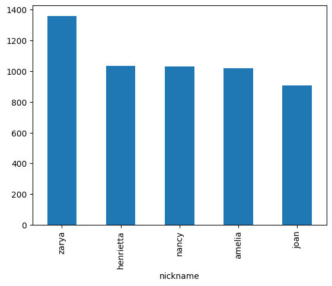

```python
passes.nickname.value_counts().plot.bar()
```

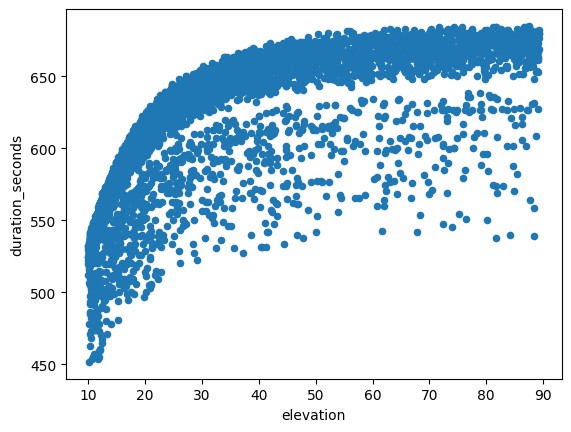

```python
passes.plot.scatter(x="elevation", y="duration_seconds")
```

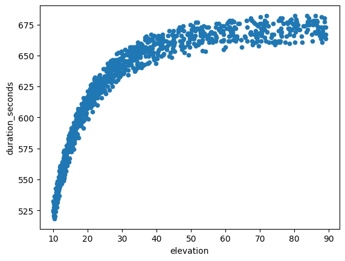

```python
passes[passes.nickname == "amelia"].plot.scatter(x="elevation", y="duration_seconds")
```

### Directo con Matplotlib

```python
from matplotlib import pyplot as plt
```

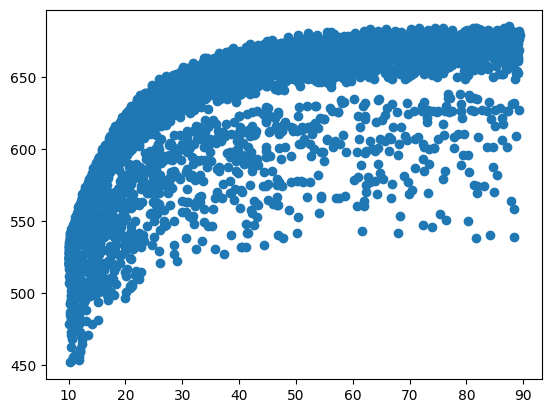

```python
plt.scatter(x=passes.elevation, y=passes.duration_seconds)
```

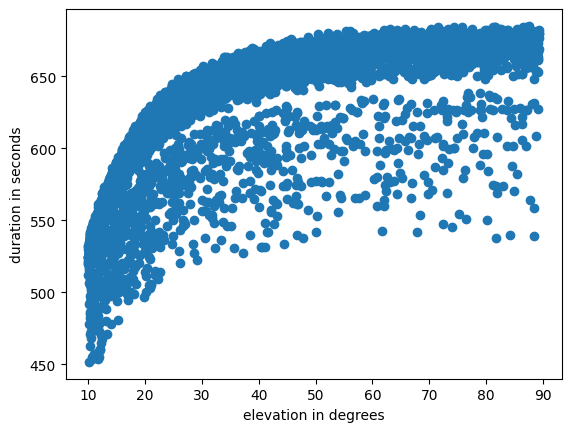

```python
plt.scatter(x=passes.elevation, y=passes.duration_seconds)
plt.xlabel("elevation in degrees")
plt.ylabel("duration in seconds")
```

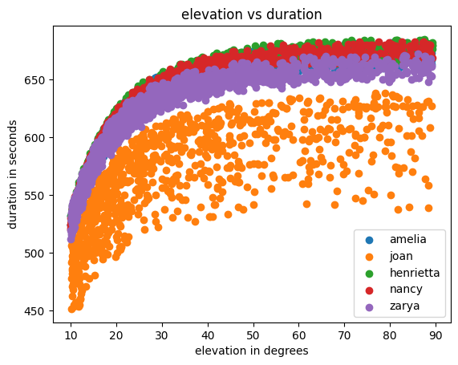

```python
for sate_nick in passes.nickname.unique():
    sate_passes = passes[passes.nickname == sate_nick]
    plt.scatter(
        x=sate_passes.elevation,
        y=sate_passes.duration_seconds,
        label=sate_nick,
    )

plt.title("elevation vs duration")
plt.xlabel("elevation in degrees")
plt.ylabel("duration in seconds")
plt.legend()
```

### Gráficos más lindos con plotly

```python
import plotly.express as px
```

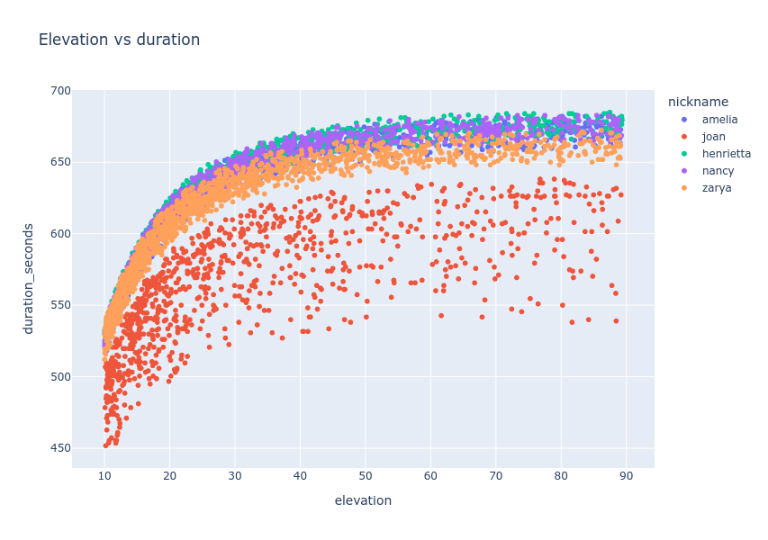

```python
px.scatter(passes, x="elevation", y="duration_seconds", color="nickname", title="Elevation vs duration",
           height=600)
```

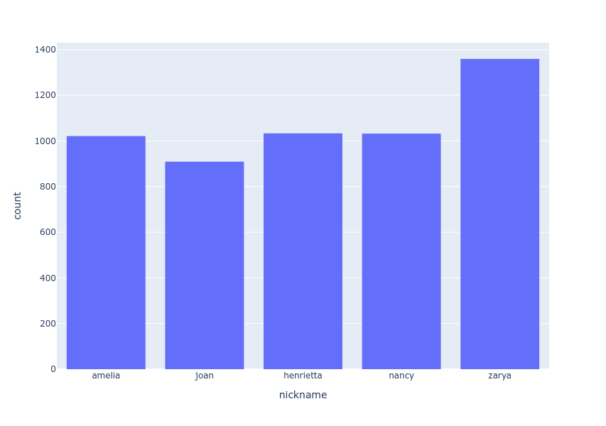

```python
px.histogram(passes, x="nickname", height=600)
```

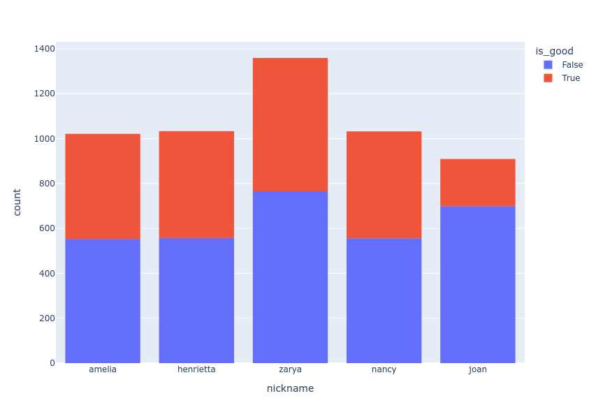

```python
px.histogram(passes, x="nickname", color="is_good", height=600)
```

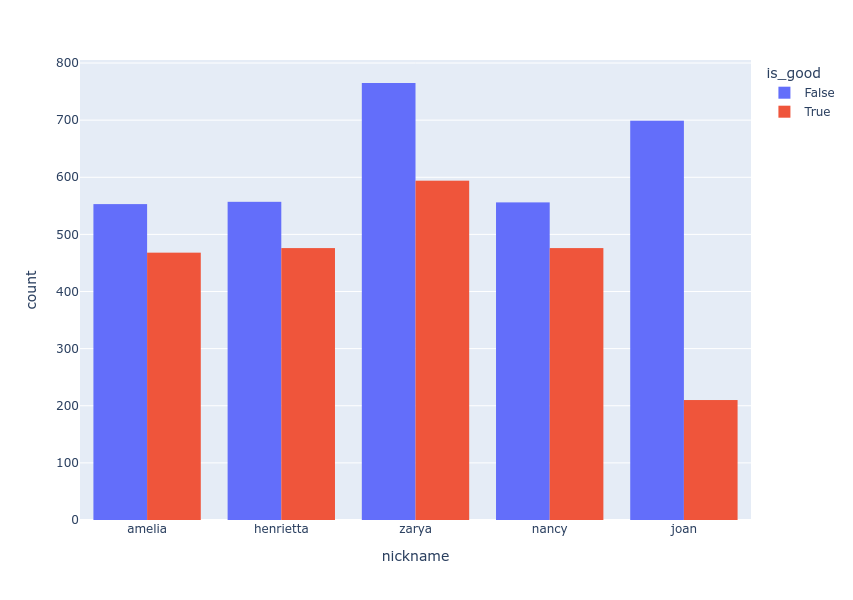

```python
px.histogram(passes, x="nickname", color="is_good", barmode="group", height=600)
```